# S&P 500 Clustering Analysis

Otajon Yuldashev

2025-01-11

# Introduction

This analysis aims to group S&P 500 stocks into clusters based on their risk and reward profiles. By leveraging clustering techniques, we identify distinct groups of stocks that can inform investment strategies. The analysis uses metrics such as average return, volatility, and market capitalization to determine meaningful clusters.

# Data processing

Objective: Prepare the datasets for analysis by cleaning, transforming, and aligning the data.

#### Data Loading:

Imported two datasets and necessary libraries:

- Historical stock prices.
- S&P 500 prices (close, open, high, low, adj.close, volume).
- S&P 500 company metadata (sectors, market cap, etc.).

```r
library(tidyverse)
library(cluster)
library(factoextra)
# Load datasets
sp500_prices <- read.csv("sp500_stocks.csv")
sp500_metadata <- read.csv("sp500_companies.csv")


# Inspect data
head(sp500_prices)
```

```
##         Date Symbol Adj.Close    Close     High      Low     Open  Volume
## 1 2010-01-04    MMM  44.01673 69.41472 69.77425 69.12207 69.47324 3640265
## 2 2010-01-05    MMM  43.74103 68.97993 69.59030 68.31104 69.23077 3405012
## 3 2010-01-06    MMM  44.36134 69.95819 70.73579 69.82442 70.13378 6301126
## 4 2010-01-07    MMM  44.39317 70.00836 70.03345 68.66221 69.66555 5346240
## 5 2010-01-08    MMM  44.70597 70.50167 70.50167 69.64883 69.97491 4073337
## 6 2010-01-11    MMM  44.52572 70.21739 70.73579 69.74081 70.55184 3500812
```

```r
head(sp500_metadata)
```

```
##   Exchange Symbol             Shortname              Longname
## 1      NMS   AAPL            Apple Inc.            Apple Inc.
## 2      NMS   NVDA    NVIDIA Corporation    NVIDIA Corporation
## 3      NMS   MSFT Microsoft Corporation Microsoft Corporation
## 4      NMS   AMZN      Amazon.com, Inc.      Amazon.com, Inc.
## 5      NMS  GOOGL         Alphabet Inc.         Alphabet Inc.
## 6      NMS   GOOG         Alphabet Inc.         Alphabet Inc.
##                   Sector                       Industry Currentprice
## 1             Technology           Consumer Electronics       254.49
## 2             Technology                 Semiconductors       134.70
## 3             Technology      Software - Infrastructure       436.60
## 4      Consumer Cyclical                Internet Retail       224.92
## 5 Communication Services Internet Content & Information       191.41
## 6 Communication Services Internet Content & Information       192.96
##      Marketcap      Ebitda Revenuegrowth          City State       Country
```

[output cut: 27 more lines]

#### Data preprocessing:

```r
# Convert Date to Date format
sp500_prices$Date <- as.Date(sp500_prices$Date)


# # Handle missing values by omitting rows with NA
sp500_prices <- na.omit(sp500_prices)


# Calculate daily returns
sp500_prices <- sp500_prices %>%
  arrange(Symbol, Date) %>%
  group_by(Symbol) %>%
  mutate(Daily_Return = log(Close) - log(lag(Close))) %>%
  ungroup() %>%
  filter(!is.na(Daily_Return))  # Remove NA values from returns
```

#### Feature Engineering:

Calculated daily returns using the formula:

$$\text{Daily_return} = \log\left(\frac{P_t}{P_{t-1}}\right)$$

Computed key metrics:

- **Average Return:** Mean of daily returns for each stock.
- **Volatility:** Standard deviation of daily returns.

Merged metadata (sector and market cap) with these computed features.

```r
# Feature Engineering: Calculate average return and volatility for each stock
features <- sp500_prices %>%
  group_by(Symbol) %>%
  summarise(
    Avg_Return = mean(Daily_Return, na.rm = TRUE),
    Volatility = sd(Daily_Return, na.rm = TRUE)
  ) %>%
  left_join(sp500_metadata %>% select(Symbol, Sector), by = "Symbol")  # Add Sector metadata
```

# Output:

# Exploratory Data Analysis (EDA)

## Objective:

Understand the distribution and relationships between key metrics.

Visualized Distributions:

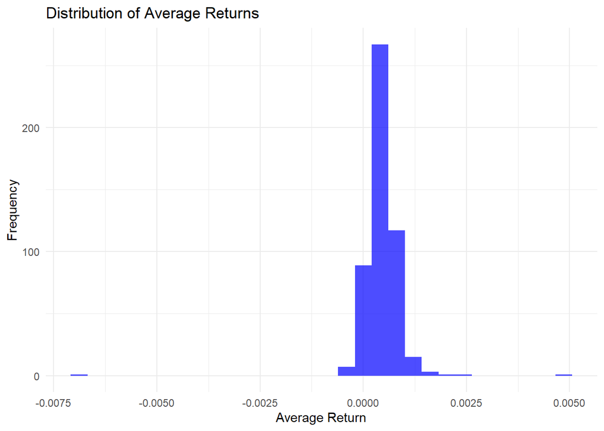

```r
# Plot distribution of average returns
ggplot(features, aes(x = Avg_Return)) +
  geom_histogram(bins = 30, fill = "blue", alpha = 0.7) +
  labs(title = "Distribution of Average Returns",
       x = "Average Return",
       y = "Frequency") +
  theme_minimal()
```

The histogram for average returns shows that most values are centered near zero, with very few large deviations. This suggests that average returns are relatively stable for most stocks, though there may be some outliers or stocks with extreme performance.

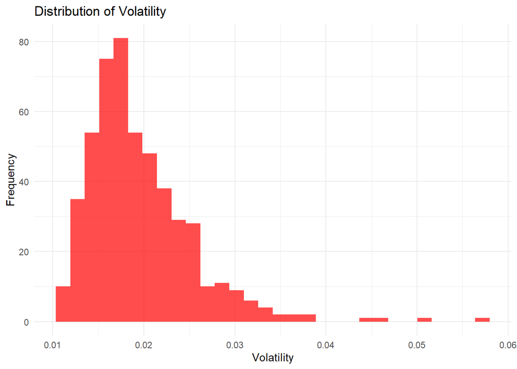

```r
# Plot distribution of volatility
ggplot(features, aes(x = Volatility)) +
  geom_histogram(bins = 30, fill = "red", alpha = 0.7) +
  labs(title = "Distribution of Volatility",
       x = "Volatility",
       y = "Frequency") +
  theme_minimal()
```

The histogram for volatility indicates a right-skewed distribution, meaning that most stocks have low volatility, but some have much higher values. This skewness is common in financial datasets and highlights that only a few stocks have very high risk or price fluctuations.

# Clustering Methodology

We scale the features because Avg_Return and Volatility have different ranges and units. Scaling ensures that both features contribute equally to the distance calculation during K-means clustering, preventing the feature with a larger range (e.g., volatility) from dominating the clustering process.

```r
# Scale features
scaled_features <- scale(features[, c("Avg_Return", "Volatility")])
```

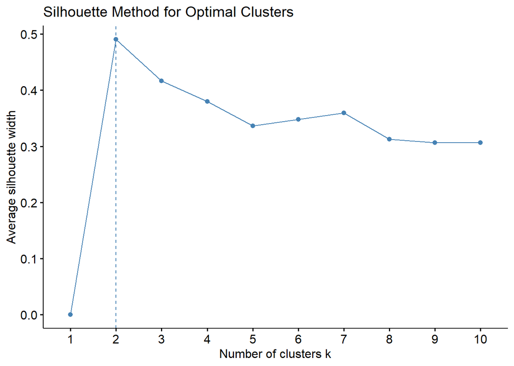

```r
# Silhouette Method for K-means
fviz_nbclust(scaled_features, kmeans, method = "silhouette") +
  labs(title = "Silhouette Method for Optimal Clusters")
```

So, in order to find optimal number of clusters for K-means clustering I used Elbow Method, but was not 100% sure of results of it as it was showing 2 clusters. So then I decided to try Silhouette method , which clearly confirmed that the number of clusters should be 2 for this fuatures. Then I decided to skip Elbow method and include silhouette method instead.

#### K-means Clustering:

Performed K-means clustering to group stocks based on average return and volatility.

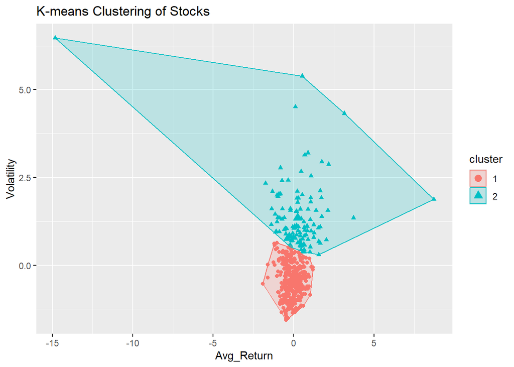

```r
# Perform K-means clustering with k = 2, because from our Elbow method we have chosen 2 clusters as optimal number.
set.seed(123)
kmeans_result <- kmeans(scaled_features, centers = 2, nstart = 25)

# Add cluster assignments to features
features$Cluster <- kmeans_result$cluster

# Visualize K-means clusters
fviz_cluster(kmeans_result, data = scaled_features,
             geom = "point", stand = FALSE,
             ellipse = TRUE) +
  labs(title = "K-means Clustering of Stocks")
```

## Overview

#### **Cluster Spread**

Cluster 1 is more tightly packed, indicating that the stocks in this group have similar, stable characteristics. On the other hand, Cluster 2 is more spread out, showing greater variability in average returns and volatility.

#### **Cluster Location**

The stocks in Cluster 2 generally have higher volatility and, in some cases, higher returns compared to Cluster 1.

# Cluster Evaluation

### Objective:

Assess the quality of the clusters and validate the clustering results.

- **Silhouette Score:** Measures how well each stock fits within its cluster compared to other clusters.

```
##   cluster size ave.sil.width
## 1       1  379          0.60
## 2       2  123          0.15
```

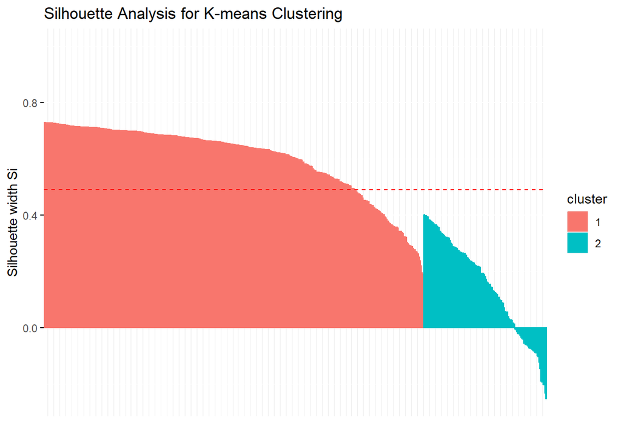

```r
# Compute silhouette score
silhouette_score <- silhouette(kmeans_result$cluster, dist(scaled_features))

# Plot silhouette analysis
fviz_silhouette(silhouette_score) +
  labs(title = "Silhouette Analysis for K-means Clustering")
```

```r
# Average silhouette width
mean_sil_width <- mean(silhouette_score[, "sil_width"])
print(paste("Average Silhouette Width: ", round(mean_sil_width, 3)))
```

```
## [1] "Average Silhouette Width:  0.49"
```

The silhouette analysis for K=2 clustering shows that Cluster 1 is well-defined, with most points having high silhouette widths. However, Cluster 2 exhibits some overlap or ambiguity, as indicated by lower silhouette widths for certain points. The overall average silhouette width of 0.49 (moderate clustering) supports the decision to use K=2.

#### **Purpose of the Plot**

This visualization helps understand the **sectoral composition** of each cluster, offering insights into the risk-return profiles of sectors within the S&P 500 stocks. It provides a useful guide for investors aiming to diversify their portfolios based on sector-specific strategies.

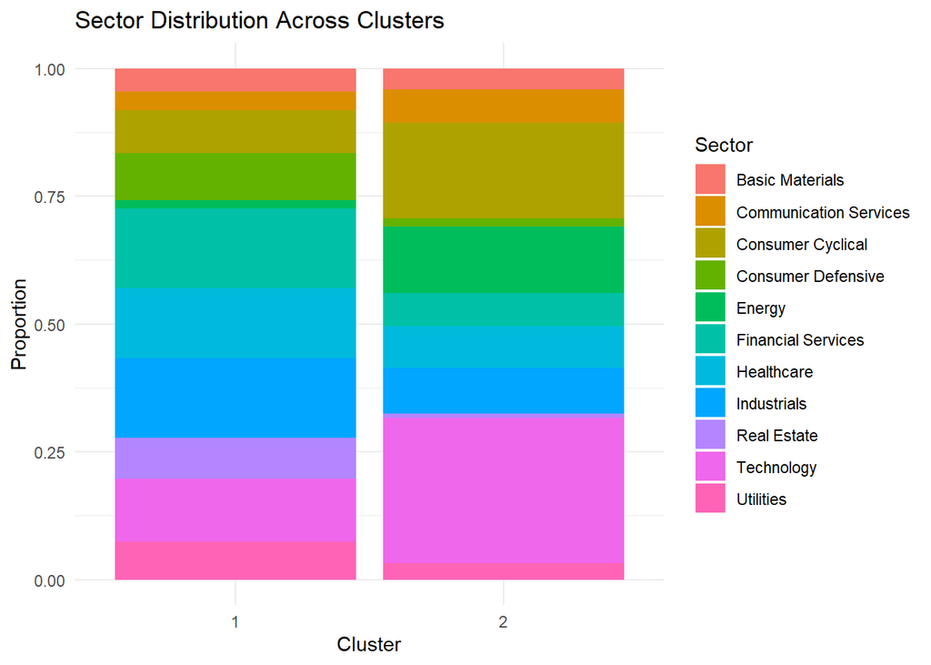

```r
# Sector distribution within clusters
ggplot(features, aes(x = as.factor(Cluster), fill = Sector)) +
  geom_bar(position = "fill") +
  labs(
    title = "Sector Distribution Across Clusters",
    x = "Cluster",
    y = "Proportion",
    fill = "Sector"
  ) +
  theme_minimal()
```

### Summary of the Sector Composition Bar Plot

This bar plot illustrates the **sectoral composition** of stocks within each cluster, highlighting the proportion of various sectors in the two clusters.

### Summary of the Box Plot

The box plot displays the **distribution of average returns** for the two clusters identified through K-means clustering:

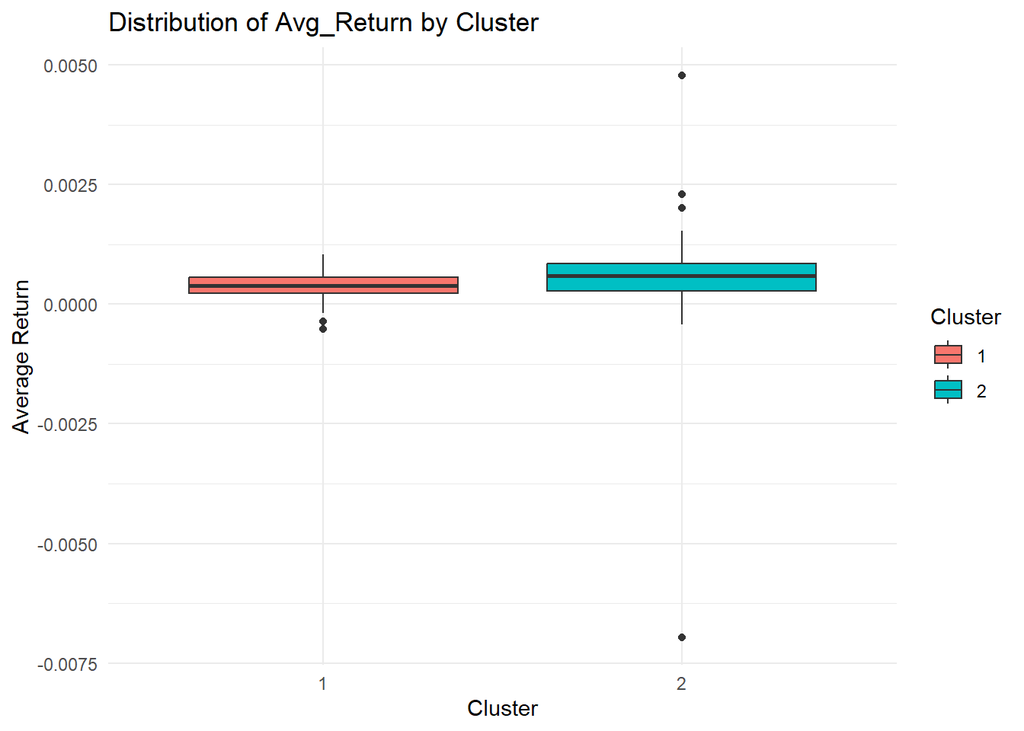

```r
ggplot(features, aes(x = as.factor(Cluster), y = Avg_Return, fill = as.factor(Cluster))) +
  geom_boxplot() +
  labs(title = "Distribution of Avg_Return by Cluster",
       x = "Cluster",
       y = "Average Return",
       fill = "Cluster") +
  theme_minimal()
```

### Key Insights

- **Cluster 1**: Consists of low-return, stable stocks with minimal variability.
- **Cluster 2**: Comprises higher-return, high-risk stocks with greater variability and potential outliers.

This visualization reinforces the **risk-return tradeoff** observed in the clustering process, providing a clear differentiation between the two clusters.

# Interpretation and Insights

This section summarizes the results from the clustering analysis and provides actionable insights based on the identified clusters.

## Cluster Profiles

```r
# Cluster summary table
cluster_summary <- features %>%
  group_by(Cluster) %>%
  summarise(
    Avg_Return = mean(Avg_Return, na.rm = TRUE),
    Volatility = mean(Volatility, na.rm = TRUE),
    Count = n()
  )

# Print the cluster summary table
knitr::kable(cluster_summary, caption = "Cluster Profiles: Summary of Key Metrics")
```

Cluster Profiles: Summary of Key Metrics

| Cluster | Avg_Return | Volatility | Count |
| --- | --- | --- | --- |
| 1 | 0.0004002 | 0.0169756 | 379 |
| 2 | 0.0005657 | 0.0272543 | 123 |

Sector Trends

```r
# Sector distribution by cluster
sector_distribution <- features %>%
  group_by(Cluster, Sector) %>%
  summarise(Count = n()) %>%
  arrange(Cluster, desc(Count))
# Print the sector distribution table
knitr::kable(sector_distribution, caption = "Sector Distribution by Cluster")
```

Sector Distribution by Cluster

| Cluster | Sector | Count |
| --- | --- | --- |
| 1 | Financial Services | 59 |
| 1 | Industrials | 59 |
| 1 | Healthcare | 52 |
| 1 | Technology | 47 |
| 1 | Consumer Defensive | 35 |
| 1 | Consumer Cyclical | 32 |
| 1 | Real Estate | 30 |
| 1 | Utilities | 28 |
| 1 | Basic Materials | 17 |
| 1 | Communication Services | 14 |
| 1 | Energy | 6 |
| 2 | Technology | 35 |
| 2 | Consumer Cyclical | 23 |
| 2 | Energy | 16 |
| 2 | Industrials | 11 |
| 2 | Healthcare | 10 |
| 2 | Communication Services | 8 |
| 2 | Financial Services | 8 |
| 2 | Basic Materials | 5 |
| 2 | Utilities | 4 |
| 2 | Consumer Defensive | 2 |
| 2 | Real Estate | 1 |

```r
# Visualize sector composition
# Calculate sector distribution by cluster
sector_distribution <- features %>%
  group_by(Cluster, Sector) %>%
  summarise(Count = n()) %>%
  arrange(Cluster, desc(Count))
# View the summarized table
View(sector_distribution)
```

### Conclusion

This project applied clustering techniques (**K-means**) to group S&P 500 stocks based on key financial metrics such as **average return**, **volatility**. The goal was to identify distinct clusters of stocks to provide actionable insights for investors.

The analysis revealed two meaningful clusters that capture different risk-return profiles and sector compositions of the stocks.

### Recommendations for Investors

#### **1. Portfolio Diversification**

- **Cluster 1**:
  - Invest in Cluster 1 stocks as a foundation for a **low-risk portfolio**.
  - Focus on defensive sectors to hedge against market volatility.
- **Cluster 2**:
  - Allocate a smaller portion of the portfolio to Cluster 2 stocks for **growth potential**.
  - Be mindful of the higher risk and volatility associated with these investments.

#### **3. Monitor Risk-Reward Balance**

- Use the clustering insights to maintain a balance between risk and reward in the portfolio.
- Reassess sector compositions periodically to adapt to changing market conditions.

This project demonstrates the value of clustering analysis in identifying distinct groups of stocks and tailoring investment strategies accordingly. K-means clustering, in particular, proved to be a robust and effective method for this dataset.

### Useful Links:

1. [K-means Clustering in R - RDocumentation](https://www.rdocumentation.org/packages/stats/versions/3.6.2/topics/kmeans)
2. [Silhouette Analysis in R - CRAN Clustering Documentation](https://cran.r-project.org/web/packages/cluster/cluster.pdf)
3. [Data Visualization in R with ggplot2 - R for Data Science](https://r4ds.had.co.nz/data-visualisation.html)
4. [Factoextra Package for Clustering Visualization in R](https://rpkgs.datanovia.com/factoextra/index.html)
5. [Data Transformation with dplyr](https://dplyr.tidyverse.org/articles/dplyr.html)